# Report

Advised by MicrobiomaLab

Diana H. Oaxaca

2024-04

# 1 Clean and remove adaptadors

Para limpiar y remover adaptadores se corrieron los siguientes scripts

```bash
#QC filter, delete nextera adapter and low quality
bash src/03.trimgalore.sh
#Remove adapters
bash src/05.cutadapt
```

# 2 Infer ASVs

Se infierieron las ASVs de cada corrida de secuenciación por separado con DADA2 en R

El código para cada corrida se encuentra en:

*2022* `src/Dada2_2022.html` *2023* `src/Dada2_2023.html`

# 3 Filter by frequence

## 3.1 Import outputs from DADA2 to QIIME2

```bash
    #Create output results dir
    mkdir -p results/02.QIIME2

#Import run 2022 files

    #import fasta seqs
    qiime tools import --input-path results/01.Dada2/2022/ASVs_2022.fasta --type 'FeatureData[Sequence]' --output-path results/02.QIIME2/ASV_rep_seq_2022.qza

    # append missing header to the table for import
    cat <(echo -n "#OTU Table") results/01.Dada2/2022/ASV_to_seqs-nochim_2022.tsv > results/02.QIIME2/temp.txt

    # convert to biom
    biom convert -i results/02.QIIME2/temp.txt -o results/02.QIIME2/temp.biom --table-type="OTU table" --to-hdf5

    #create feature table
    qiime tools import --input-path results/02.QIIME2/temp.biom --type 'FeatureTable[Frequency]' --input-format BIOMV210Format --output-path results/02.QIIME2/ASV_table_2022.qza

    #Get visual summarizes
    qiime feature-table tabulate-seqs \
    --i-data results/02.QIIME2/ASV_rep_seq_2022.qza \
    --o-visualization results/02.QIIME2/ASV_rep_seq_2022.qzv

    qiime feature-table summarize \
    --i-table results/02.QIIME2/ASV_table_2022.qza \
    --o-visualization results/02.QIIME2/ASV_table_2022.qzv

#Import run 2023 files

    #import fasta seqs
    qiime tools import --input-path results/01.Dada2/2023/ASVs_2023.fasta --type 'FeatureData[Sequence]' --output-path results/02.QIIME2/ASV_rep_seq_2023.qza

    # append missing header to the table for import
    cat <(echo -n "#OTU Table") results/01.Dada2/2023/ASV_to_seqs-nochim_2023.tsv > results/02.QIIME2/temp2.txt

    # convert to biom
    biom convert -i results/02.QIIME2/temp2.txt -o results/02.QIIME2/temp2.biom --table-type="OTU table" --to-hdf5

    #create feature table
    qiime tools import --input-path results/02.QIIME2/temp2.biom --type 'FeatureTable[Frequency]' --input-format BIOMV210Format --output-path results/02.QIIME2/ASV_table_2023.qza

    #Get visual summarizes
    qiime feature-table tabulate-seqs \
    --i-data results/02.QIIME2/ASV_rep_seq_2023.qza \
    --o-visualization results/02.QIIME2/ASV_rep_seq_2023.qzv

    qiime feature-table summarize \
    --i-table results/02.QIIME2/ASV_table_2023.qza \
    --o-visualization results/02.QIIME2/ASV_table_2023.qzv
```

## 3.2 Filter by frequence

Here I removed all ASVs with a frequency of less than 0.1% of the mean sample depth. This cut-off excludes ASVs that are likely due to MiSeq bleed-through between runs (reported by Illumina to be 0.1% of reads). To calculate this cut-off I identified the mean sample depth, multiplied it by 0.001, and rounded to the nearest integer. This step are describe in [this paper](https://journals.asm.org/doi/pdf/10.1128/msystems.00127-16)

```bash
# 2022
#Filter feature table by frequence
qiime feature-table filter-features --i-table  results/02.QIIME2/ASV_table_2022.qza --p-min-samples 1 --p-min-frequency 52 --o-filtered-table results/02.QIIME2/ASV_table_2022_freq52_1minsamp.qza

#Get visual feature table summary
qiime feature-table summarize --i-table results/02.QIIME2/ASV_table_2022_freq52_1minsamp.qza --o-visualization results/02.QIIME2/ASV_table_2022_freq52_1minsamp.qzv

#Filter rep-seqs 2022
qiime feature-table filter-seqs  --i-table results/02.QIIME2/ASV_table_2022_freq52_1minsamp.qza --i-data results/02.QIIME2/ASV_rep_seq_2022.qza --o-filtered-data results/02.QIIME2/ASV_rep_seq_2022_filter-freq52.qza

# 2023
#Filter feature table by frequence
qiime feature-table filter-features --i-table  results/02.QIIME2/ASV_table_2023.qza --p-min-samples 1 --p-min-frequency 97 --o-filtered-table results/02.QIIME2/ASV_table_2023_freq97_1minsamp.qza

#Get visual feature table summary
qiime feature-table summarize --i-table results/02.QIIME2/ASV_table_2023_freq97_1minsamp.qza --o-visualization results/02.QIIME2/ASV_table_2023_freq97_1minsamp.qzv

#Filter rep-seqs 2023
qiime feature-table filter-seqs  --i-table results/02.QIIME2/ASV_table_2023_freq97_1minsamp.qza --i-data results/02.QIIME2/ASV_rep_seq_2023.qza --o-filtered-data results/02.QIIME2/ASV_rep_seq_2023_filter-freq97.qza
```

# 4 Merge sequences and feature tables

> Inicialmente hice el merge sin filtrar por frecuencia

> ```
> #Merge rep seqs
> qiime feature-table merge-seqs  --i-data results/02.QIIME2/ASV_rep_seq_2022.qza results/02.QIIME2/ASV_rep_seq_2023.qza   --o-merged-data results/02.QIIME2/merged-rep_seqs.qza
>
> #Merge feature tables
> qiime feature-table merge --i-tables results/02.QIIME2/ASV_table_2022.qza results/02.QIIME2/ASV_table_2023.qza --p-overlap-method sum --o-merged-table results/02.QIIME2/merged-table.qza
>
> #Get visual summarizes
> qiime feature-table tabulate-seqs --i-data results/02.QIIME2/merged-rep_seqs.qza --o-visualization results/02.QIIME2/merged-rep_seqs.qzv
>
> qiime feature-table summarize --i-table results/02.QIIME2/merged-table.qza --o-visualization results/02.QIIME2/merged-table.qzv
>
>
> ## Merge by clustering
>
>
> #Explore how many ASVs are recovered if clustering
>
> #Cluster to 100 %
> qiime vsearch cluster-features-de-novo --p-threads 80 --i-table results/02.QIIME2/merged-table.qza --i-sequences results/02.QIIME2/merged-rep_seqs.qza --p-perc-identity 1 --o-clustered-table results/02.QIIME2/merged-table-dn-100.qza --o-clustered-sequences results/02.QIIME2/merged-rep-seqs-dn-100.qza
>
> qiime feature-table tabulate-seqs --i-data results/02.QIIME2/merged-rep-seqs-dn-100.qza --o-visualization results/02.QIIME2/merged-rep-seqs-dn-100.qzv
>
> qiime feature-table summarize --i-table results/02.QIIME2/merged-table-dn-100.qza --o-visualization results/02.QIIME2/merged-table-dn-100.qzv
>
> #Cluster to 99 %
> qiime vsearch cluster-features-de-novo --p-threads 80 --i-table results/02.QIIME2/merged-table.qza --i-sequences results/02.QIIME2/merged-rep_seqs.qza --p-perc-identity 0.99 --o-clustered-table results/02.QIIME2/merged-table-dn-99.qza --o-clustered-sequences results/02.QIIME2/merged-rep-seqs-dn-99.qza
>
> qiime feature-table tabulate-seqs --i-data results/02.QIIME2/merged-rep-seqs-dn-99.qza --o-visualization results/02.QIIME2/merged-rep-seqs-dn-99.qzv
> qiime feature-table summarize --i-table results/02.QIIME2/merged-table-dn-99.qza --o-visualization results/02.QIIME2/merged-table-dn-99.qzv
>
> ## Compare merge
>
> Cuando visualizo los ASVs inferidos en cada secuenciación y al juntar las tablas y secuencias tanto con el merge como con la clusterización, obtenemos los siguientes valores:
>
>
> | Type        | ASVs  | Frequency | Samples |
> | ----------- | ----- | --------- | ------- |
> | 2022        | 29302 | 2677260   | 53      |
> | 2023        | 19143 | 3035299   | 30      |
> | Merge       | 29302 | 5712559   | 83      |
> | Cluster-100 | 29300 | 5712559   | 83      |
> | Cluster-99  | 19449 | 5712559   | 83      |
>
> Entonces creo que lo adecuado es quedarme con el merge inicial
> ```

Después de hacer el merge, el clustering y la comparación creo que la opción adecuada es el merge simple. También considero que debo hacer el merge después de hacer el filtrado por frecuencia de cada corrida de secuenciación, pues al ser diferentes la frecuencia también lo es. Así que el merge final es el que se describe a continuación:

## 4.1 Merge

```bash
#Merge rep seqs
qiime feature-table merge-seqs  --i-data results/02.QIIME2/ASV_rep_seq_2022_filter-freq52.qza results/02.QIIME2/ASV_rep_seq_2023_filter-freq97.qza   --o-merged-data results/02.QIIME2/merged-rep_seqs_filters_freq52-97.qza

#Merge feature tables
qiime feature-table merge --i-tables results/02.QIIME2/ASV_table_2022_freq52_1minsamp.qza results/02.QIIME2/ASV_table_2023_freq97_1minsamp.qza --p-overlap-method sum --o-merged-table results/02.QIIME2/merged-table-filters-freq52-97.qza

#Get visual summarizes
qiime feature-table tabulate-seqs --i-data results/02.QIIME2/merged-rep_seqs_filters_freq52-97.qza --o-visualization results/02.QIIME2/merged-rep_seqs_filters_freq52-97.qzv

qiime feature-table summarize --i-table results/02.QIIME2/merged-table-filters-freq52-97.qza --o-visualization results/02.QIIME2/merged-table-filters-freq52-97.qzv
```

En la siguiente tabla se observan los ASVs obtenidos por corrida, antes y después de filtrar por frecuencia y también al hacer el merge de las corridas de secuenciación.

| Type | ASVs | Frequency | Samples |
| --- | --- | --- | --- |
| 2022 | 29302 | 2677260 | 53 |
| 2023 | 19143 | 3035299 | 30 |
| Merge | 29302 | 5712559 | 83 |
| Cluster-100 | 29300 | 5712559 | 83 |
| Cluster-99 | 19449 | 5712559 | 83 |
| 2022-filter-freq | 6316 | 2410664 | 53 |
| 2023-filter-freq | 2935 | 2754795 | 30 |
| Merge | 6316 | 5165459 | 83 |

# 5 Taxonomy assignment

```bash
#Tax classification
qiime feature-classifier classify-sklearn --i-classifier data/dbs/classifier_silva_138_trained.qza --i-reads results/02.QIIME2/merged-rep_seqs_filters_freq52-97.qza --o-classification results/02.QIIME2/taxonomy_merge.qza --p-n-jobs 80

#get visualization
qiime metadata tabulate --m-input-file results/02.QIIME2/taxonomy_merge.qza --o-visualization results/02.QIIME2/taxonomy_merge.qzv
```

# 6 Filter by taxonomy

```bash
qiime taxa filter-table --i-table results/02.QIIME2/merged-table-filters-freq52-97.qza --i-taxonomy results/02.QIIME2/taxonomy_merge.qza --p-exclude Archaea,Eukaryota,Mitochondria,Chloroplast --p-include p__ --o-filtered-table results/02.QIIME2/ASV_table_filter_freq_merge_aemc.qza

qiime feature-table summarize --i-table results/02.QIIME2/ASV_table_filter_freq_merge_aemc.qza --o-visualization results/02.QIIME2/ASV_table_filter_freq_merge_aemc.qzv
```

| Type | ASVs | Frequency | Samples |
| --- | --- | --- | --- |
| 2022 | 29302 | 2677260 | 53 |
| 2023 | 19143 | 3035299 | 30 |
| 2022-filter-freq | 6316 | 2410664 | 53 |
| 2023-filter-freq | 2935 | 2754795 | 30 |
| Merge-fltr-freq | 6316 | 5165459 | 83 |
| Mrg-fltr-freq-aemc | 6261 | 5084303 | 83 |

## 6.1 Remove in fasta seqs

```bash
#remove in fasta sequences
qiime feature-table filter-seqs  --i-table results/02.QIIME2/ASV_table_filter_freq_merge_aemc.qza --i-data results/02.QIIME2/merged-rep_seqs_filters_freq52-97.qza --o-filtered-data results/02.QIIME2/ASV_rep_seq_filters_freq_merge_aemc.qza
```

# 7 Phylogeny

```bash
nohup qiime phylogeny align-to-tree-mafft-iqtree \
--p-n-threads auto --i-sequences results/02.QIIME2/ASV_rep_seq_filters_freq_merge_aemc.qza \
--o-alignment results/02.QIIME2/align-mft-iqt.qza \
--o-masked-alignment results/02.QIIME2/masked-align-iqtree.qza \
--o-tree results/02.QIIME2/unrooted-tree-iqtree.qza \
--o-rooted-tree results/02.QIIME2/rooted-tree-iqtree.qza --verbose > outs/07.phylogeny-iqtree.nohup &
[1] 2166700
```

# 8 Get info per sample

```bash
#taxonomy
qiime tools export --input-path results/02.QIIME2/taxonomy_merge.qza --output-path results/02.QIIME2/exports/taxonomy

#feature table
qiime tools export --input-path results/02.QIIME2/ASV_table_filter_freq_merge_aemc.qza --output-path results/02.QIIME2/exports/ASV_table

#reformat taxonomy tsv
sed -i -e '1 s/Feature/#Feature/' -e '1 s/Taxon/taxonomy/' results/02.QIIME2/exports/taxonomy/taxonomy.tsv

#Add taxonomy to feature table
biom add-metadata -i results/02.QIIME2/exports/ASV_table/feature-table.biom -o results/02.QIIME2/exports/feature-table_tax.biom --observation-metadata-fp results/02.QIIME2/exports/taxonomy/taxonomy.tsv --sc-separated results/02.QIIME2/exports/taxonomy/taxonomy.tsv

#Convert to tsv from biom format
biom convert -i results/02.QIIME2/exports/feature-table_tax.biom -o results/02.QIIME2/exports/feature-table_tax.tsv --to-tsv --header-key taxonomy

#Get effective reads per sample
biom summarize-table -i results/02.QIIME2/exports/feature-table_tax.biom -o results/02.QIIME2/exports/feature-table_tax_reads_per_sample_summary.txt

#Get ASVs per sample
biom summarize-table -i results/02.QIIME2/exports/feature-table_tax.biom --qualitative -o results/02.QIIME2/exports/feature-table_tax_ASVs_per_sample_summary.txt
```

# 9 Alpha diversity

```r
# load data
otu_table <- read_qza("results/02.QIIME2/ASV_table_filter_freq_merge_aemc.qza")$data
metadata <- read.delim("data/metadata.tsv", check.names = F)
```

## 9.1 Get Hill numbers

```r
# Get hill numbers
q0 <- hill_div(otu_table, qvalue = 0)
q1 <- hill_div(otu_table, qvalue = 1)
q2 <- hill_div(otu_table, qvalue = 2)

# Merge metadata with Hill numbers
q012 <- cbind(q0, q1, q2) %>% as.data.frame() %>% rownames_to_column(var = "sample-id")
metadata_with_hill <- q012 %>%
  inner_join(metadata, by = c("sample-id"="sample-id"))

metadata_with_hill %>% head() %>% kable()
```

| sample-id | q0 | q1 | q2 | sample | Source | Date | Year | Location | Week | Raw reads | Colect_number | Specimen | quant_reading | Effective_reads | ASVs |
| --- | --- | --- | --- | --- | --- | --- | --- | --- | --- | --- | --- | --- | --- | --- | --- |
| DR1014-E | 135 | 9.036873 | 3.171788 | DR1014-E | Stipe | sep-30 | 2021 | Monte obscuro Emiliano Zapata | 1 | 159896 | DRamos 1014 | Ind_1 | 948 | 68295 | 135 |
| DR1014-SAH | 2118 | 1145.961220 | 576.966109 | DR1014-SAH | Soil associated | sep-30 | 2021 | Monte obscuro Emiliano Zapata | 1 | 223804 | DRamos 1014 | Ind_1 | 3071 | 40974 | 2118 |
| DR1015-SAH | 2013 | 1017.330538 | 382.229265 | DR1015-SAH | Soil associated | sep-30 | 2021 | Monte obscuro Emiliano Zapata | 1 | 170670 | DRamos 1015 | Ind_2 | 3664 | 33175 | 2013 |
| DR1018-E | 768 | 47.874948 | 5.350837 | DR1018-E | Stipe | oct-07 | 2021 | Monte obscuro Emiliano Zapata | 2 | 68578 | DRamos 1018 | Ind_3 | 97 | 23890 | 768 |
| DR1018-SAH | 1824 | 887.566616 | 436.200764 | DR1018-SAH | Soil associated | oct-07 | 2021 | Monte obscuro Emiliano Zapata | 2 | 211120 | DRamos 1018 | Ind_3 | 4017 | 38161 | 1824 |
| DR1019-E | 1012 | 447.167799 | 145.072574 | DR1019-E | Stipe | oct-07 | 2021 | Monte obscuro Emiliano Zapata | 2 | 144270 | DRamos 1019 | Ind_4 | 215 | 33853 | 1012 |

## 9.2 Correlation Hill vs depth

**Alpha diversity depth correlation to order q=0**

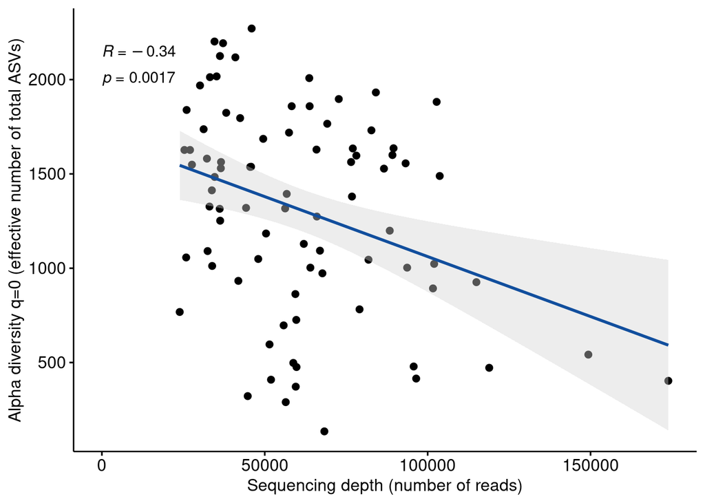

```r
#install.packages("ggpubr")
library(ggpubr)
q0_vs_depth <- ggscatter(metadata_with_hill,
                         x = "Effective_reads",
                         y = "q0",
                         xlab= "Sequencing depth (number of reads)",
                         ylab="Alpha diversity q=0 (effective number of total ASVs)",
   add = "reg.line",  # Add regression line
   add.params = list(color = "#114e9d", fill = "lightgray"), # Customize reg. line
   conf.int = TRUE, # Add confidence interval
   cor.coef = TRUE, # Add correlation coefficient. see ?stat_cor
   cor.coeff.args = list(method = "pearson", label.x = 3, label.sep = "\n")
   )+
  theme(legend.title = element_blank(), legend.position = "none")
q0_vs_depth
```

**Alpha diversity depth correlation to order q=1**

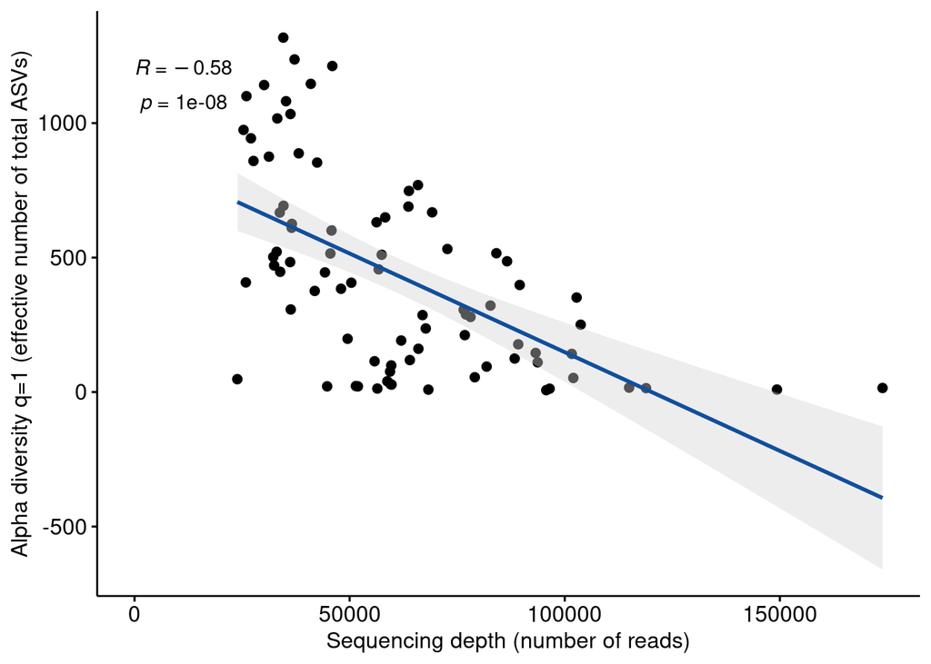

```r
q1_vs_depth <- ggscatter(metadata_with_hill,
                         x = "Effective_reads",
                         y = "q1",
                         xlab= "Sequencing depth (number of reads)",
                         ylab="Alpha diversity q=1 (effective number of total ASVs)",
   add = "reg.line",  # Add regression line
   add.params = list(color = "#114e9d", fill = "lightgray"), # Customize reg. line
   conf.int = TRUE, # Add confidence interval
   cor.coef = TRUE, # Add correlation coefficient. see ?stat_cor
   cor.coeff.args = list(method = "pearson", label.x = 3, label.sep = "\n")
   )+
  theme(legend.title = element_blank(), legend.position = "none")
q1_vs_depth
```

**Alpha diversity depth correlation to order q=2**

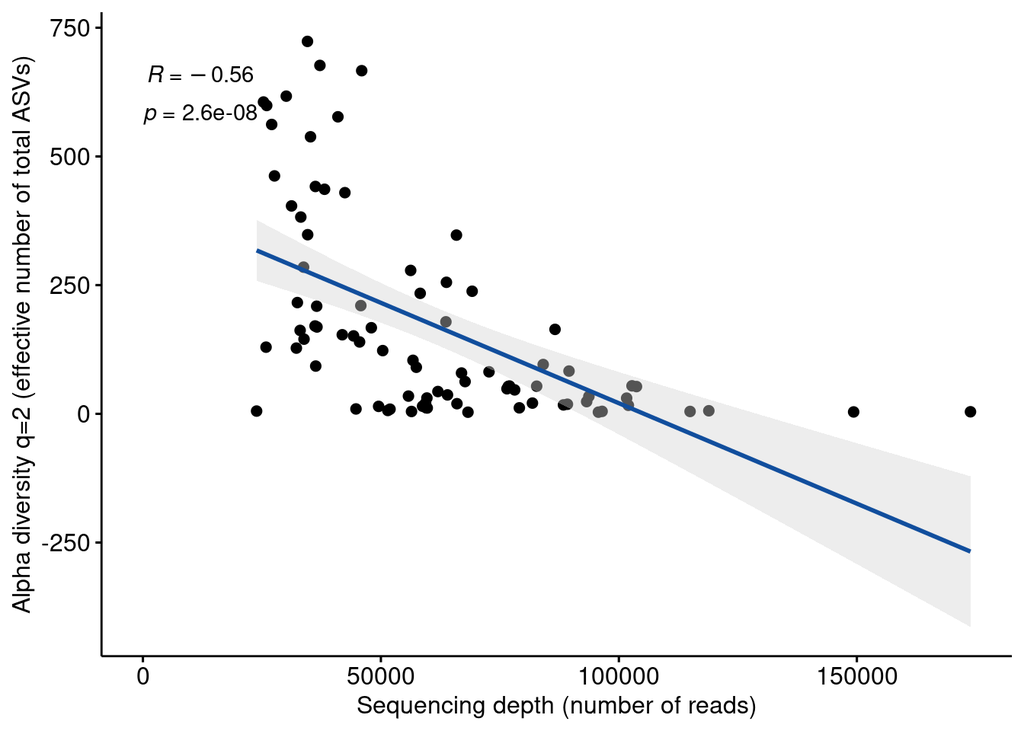

```r
q2_vs_depth <- ggscatter(metadata_with_hill,
                         x = "Effective_reads",
                         y = "q2",
                         xlab= "Sequencing depth (number of reads)",
                         ylab="Alpha diversity q=2 (effective number of total ASVs)",
   add = "reg.line",  # Add regression line
   add.params = list(color = "#114e9d", fill = "lightgray"), # Customize reg. line
   conf.int = TRUE, # Add confidence interval
   cor.coef = TRUE, # Add correlation coefficient. see ?stat_cor
   cor.coeff.args = list(method = "pearson", label.x = 3, label.sep = "\n")
   )+
  theme(legend.title = element_blank(), legend.position = "none")
q2_vs_depth
```